# Simulating SOC Measurement

Jake Spertus

October 31st, 2019

```r
library(tidyverse)
source("sim_functions.R")
```

## Goals

This notebook serves to describe and implement a simulation to test the procedures currently used to measure soil organic carbon (SOC) against a known groundtruth. Questions to be answered include:

- With what accuracy can we recover true SOC on average (mean squared error)?
- Are estimates of SOC likely to center on the truth (bias)?
- Are estimates of uncertainty (standard errors) reflecting the true degree of uncertainty in the estimates (coverage of confidence intervals / type 1 error rate)?

## Empirical Input: The Marin Data

Simulations will be based off of samples from Marin County collected by the Silver Lab at UC Berkeley.

```r
duplicate_data <- read_csv("mcp_duplicates.csv")
#drop samples that were rerun fewer or more than 2 times
no_dups <- names(which(table(duplicate_data$sample_name) < 2))
#also drop runs of atropine standards
duplicate_data <- duplicate_data %>%
  filter(!(sample_name %in% no_dups)) %>%
  filter(!(substr(sample_name, 1, 4) %in% c('atro','blan','Blan','dumm','Dumm'))) %>%
  group_by(sample_name) %>%
  filter(rank(time) <= 2)

duplicate_data
```

| index | sample_name | filename | data | time | type | weight | nitrogen | carbon |
| --- | --- | --- | --- | --- | --- | --- | --- | --- |
| 8 | WR 3-2 50-100 | cw051608 | 5/19/00 | 10:44:00 | UNK | 27.966 | 0.07 | 0.49 |
| 9 | WR 3-2 50-100 | cw051609 | 5/19/00 | 10:50:00 | UNK | 27.233 | 0.07 | 0.49 |
| 10 | WR 3-1 10-30 | cw051610 | 5/19/00 | 10:56:00 | UNK | 25.587 | 0.19 | 2.09 |
| 11 | WR 3-1 10-30 | cw051611 | 5/19/00 | 11:02:00 | UNK | 25.834 | 0.20 | 2.12 |
| 12 | WR 3-1 30-50 | cw051612 | 5/19/00 | 11:08:00 | UNK | 26.458 | 0.12 | 1.38 |
| 13 | WR 3-1 30-50 | cw051613 | 5/19/00 | 11:14:00 | UNK | 26.045 | 0.12 | 1.33 |
| 14 | WR 3-1 0-10 | cw051614 | 5/19/00 | 11:20:00 | UNK | 26.120 | 0.30 | 3.34 |
| 15 | WR 3-1 0-10 | cw051615 | 5/19/00 | 11:26:00 | UNK | 25.848 | 0.31 | 3.49 |
| 16 | WR 3-2 0-10 | cw051616 | 5/19/00 | 11:32:00 | UNK | 25.474 | 0.34 | 3.91 |
| 17 | WR 3-2 0-10 | cw051617 | 5/19/00 | 11:38:00 | UNK | 27.050 | 0.33 | 3.84 |

[output cut: 666 more lines]

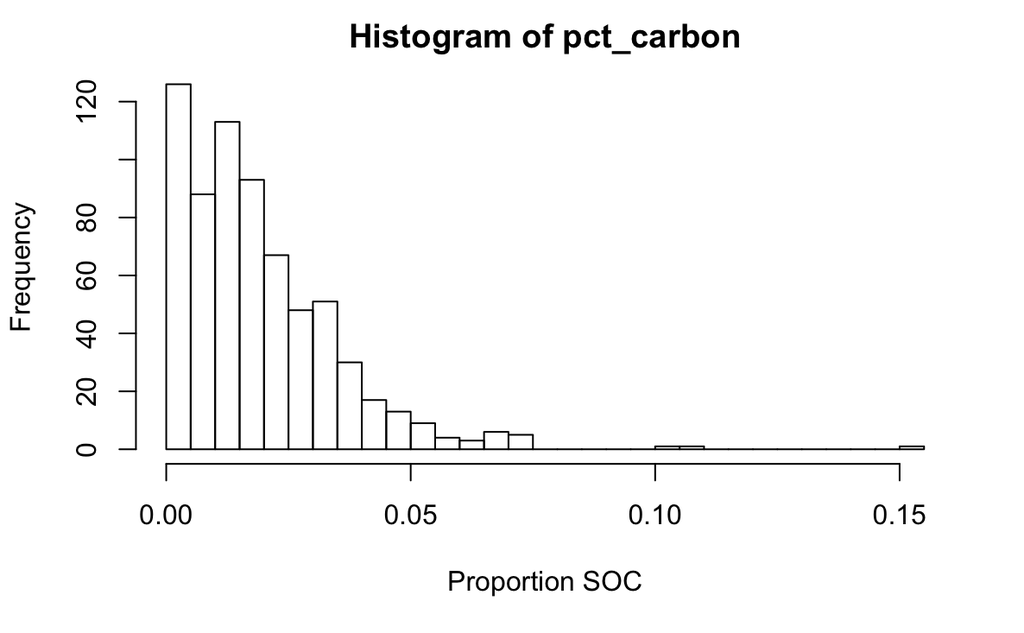

```r
pct_carbon <- duplicate_data$carbon / 100
hist(pct_carbon, breaks = 30, xlab = "Proportion SOC")
```

## Simulating Percent SOC

However, simulating a field of % SOC is not entirely straightforward. In particular we would like to generate numbers that:

- Are bounded between 0 and 1 (0% and 100% SOC).
- Allow for arbitrary correlation between points.
- Have an adjustable mean and variance.

```r
source("sim_functions.R")

test_sim <- simulate_truth(size = c(250,600), nugget = .01, sill = .05, range = 20, intercept = .01, y_trend = TRUE, max_mean = .2)
```

```
[using unconditional Gaussian simulation]
```

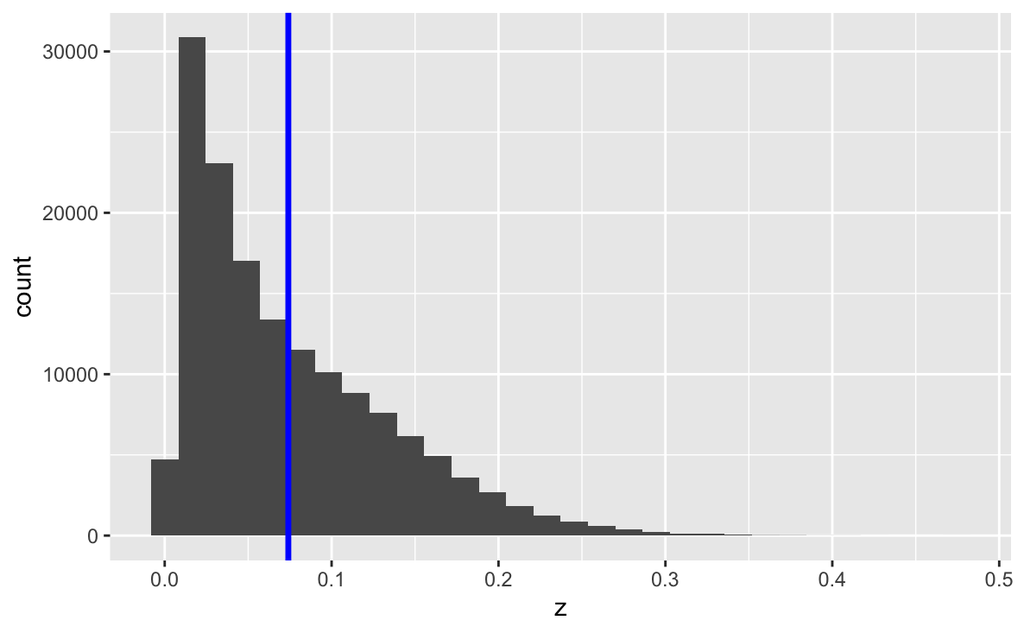

```r
#marginal histogram
sim_hist <- ggplot(data = test_sim, aes(z)) +
  geom_histogram(bins = 30) +
  geom_vline(xintercept = mean(test_sim$z), size = 1.2, color = 'blue')
sim_hist
```

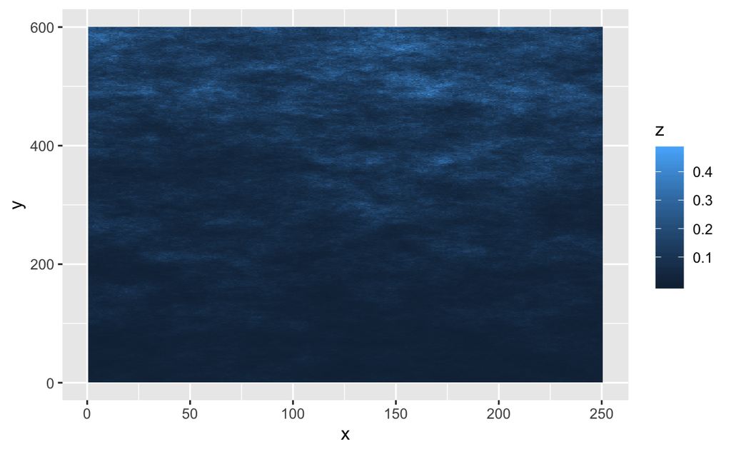

```r
#surface
sim_plot <- ggplot(data = test_sim, aes(x = x, y = y, fill = z)) +
  geom_raster()
sim_plot
```

# Sampling

# Measurement

Once samples have been taken, error in the assay itself remains a concern. The Silver lab takes duplicate measurements until two runs are within 10% of each other (this often happens after the first two runs of any given sample). These percent differences are computed as:

$$\delta = 100 * \bigg | \frac{x_1 - x_2}{\frac{1}{2}(x_1 + x_2)} \bigg |$$

I add in measurement noise for each point by drawing a random sample from the observed percent differences between the Marin County duplicates, and then adding uniform noise at the scale of the sampled percent difference.

```r
abs_diff <- function(x){
  abs(x[1] - x[2])
}
pct_diff <- function(x){
  2 * 100 * abs((x[1] - x[2]) / (x[1] + x[2]))
}
pct_differences <- duplicate_data %>%
  group_by(sample_name) %>%
  summarize(N_pct_diff = pct_diff(nitrogen), C_pct_diff = pct_diff(carbon), N_abs_diff = abs_diff(nitrogen), C_abs_diff = abs_diff(carbon), C_mean = mean(carbon), N_mean = mean(nitrogen), C_range = abs(diff(carbon)))
```

# Analysis

According to [Ryals et al 2014](https://www.sciencedirect.com/science/article/abs/pii/S003807171300312X), the carbon stock in a plot is computed by averaging the samples and then multiplying by the bulk density measurement. These averages are then treated as fixed and analyzed with ANOVA for final inference about treatment effects.

# Simulations

We first generate 10 plots (5 treatment, 5 control) using the simulation set up above. All surfaces are generated in exactly the same way so that the true treatment effect is 0. Then we run 1000 simulations of the sampling, measurement, and analysis schemes as described above.

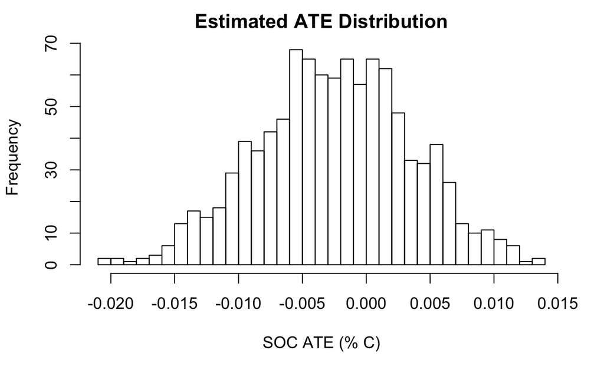

```r
#surfaces <- lapply(1:10, simulate_truth)
#save(surfaces, file = "simulated_surfaces")
load("simulated_surfaces")
treatment <- c(rep(1, 5), rep(0, 5))

#run simulations
simulation_results <- run_sims(n_sims = 1000, surfaces = surfaces, pct_perturbations = pct_differences$C_pct_diff, treatment = treatment)

avg_estimated_std_error <- mean(simulation_results[,3])
true_std_error <- sd(simulation_results[,2])
type_1_error_rate <- mean(simulation_results[,4] < .05)
hist(simulation_results[,2], xlab = "SOC ATE (% C)", main = "Estimated ATE Distribution", breaks = 30)
```